# Optimizing Training Size for Housing Sales Forecasts

Sean Schilk

11/23/2025

# 1 Data Description

The data is from the census.gov site: Annual Rate for New Single-family Houses Sold: United States — Seasonally Adjusted All Houses [Thousands of Units], from the years 1963 to 2025. We only use look at monthly data between Jun, 2007 and Dec, 2019.

```r
newHouse <- read.csv("https://sschilk.github.io/MySTA321/SeriesReport-202511231154-V.csv")
n.row = dim(newHouse)[1]
data.newHouse = newHouse[(n.row-150):n.row, ]
```

# 2 Define Time Series Object

Since this is monthly data, frequency =12 will be used the define the time series object.

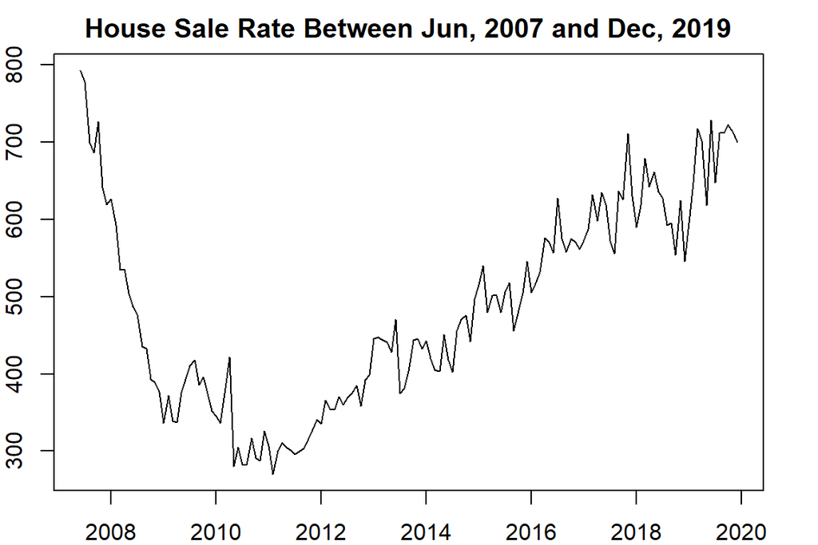

```r
data.newHouse$X.1 <- as.numeric(gsub(",", "", data.newHouse$X.1))
newHouse.ts = ts(data.newHouse[,2], frequency = 12, start = c(2007, 6))
par(mar=c(2,2,2,2))
plot(newHouse.ts, main="House Sale Rate Between Jun, 2007 and Dec, 2019", ylab="Monthly Rate", xlab="")
```

# 3 Forecasting with Decomposing

We use stl decomp to extract the nonlinear trend

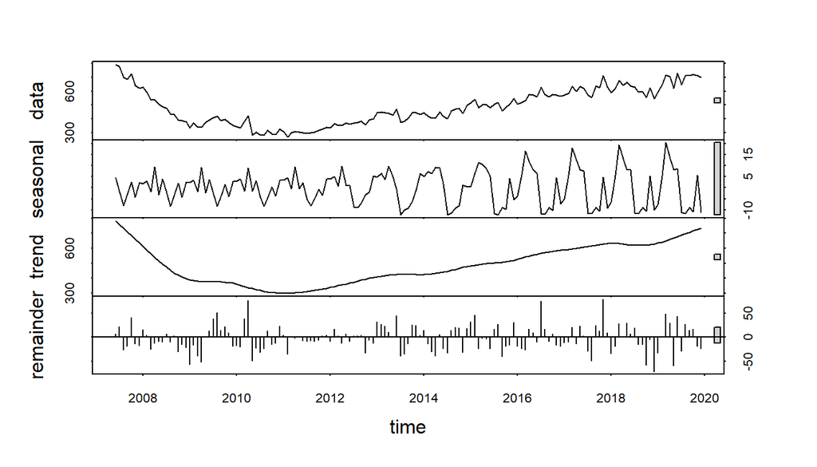

STL decomposition of additive time series

```r
stl.decomp=stl(newHouse.ts, s.window = 12)
par(mar=c(2,2,2,2))
plot(stl.decomp)
```

We’ll use **rwdrift** for forecasting because the housing sales series exhibits an upward trend.

**Training and Testing Data**

We hold up the **last 7 periods** of data for testing. The rest of the historical data will be used to train the forecast model.

We are producing predictions based on the non linear trend we found previously.

```r
ini.data = data.newHouse[,2]
n0 = length(ini.data)
train.data01 = data.newHouse[1:(n0-7), 2]
train.data02 = data.newHouse[37:(n0-7), 2]
train.data03 = data.newHouse[73:(n0-7), 2]
train.data04 = data.newHouse[97:(n0-7), 2]
## last 7 observations
test.data = data.newHouse[(n0-6):n0,2]
train01.ts = ts(train.data01, frequency = 12, start = c(2008, 1))
train02.ts = ts(train.data02, frequency = 12, start = c(2011, 1))
train03.ts = ts(train.data03, frequency = 12, start = c(2014, 1))
train04.ts = ts(train.data04, frequency = 12, start = c(2016, 1))
stl01 = stl(train01.ts, s.window = 12)
stl02 = stl(train02.ts, s.window = 12)
stl03 = stl(train03.ts, s.window = 12)
stl04 = stl(train04.ts, s.window = 12)
## Forecast with decomposing
fcst01 = forecast(stl01,h=7, method="rwdrift")
fcst02 = forecast(stl02,h=7, method="rwdrift")
fcst03 = forecast(stl03,h=7, method="rwdrift")
fcst04 = forecast(stl04,h=7, method="rwdrift")
```

We next perform error analysis.

```r
## To compare different errors, we will not use the percentage for MAPE
PE01=(test.data-fcst01$mean)/fcst01$mean
PE02=(test.data-fcst02$mean)/fcst02$mean
PE03=(test.data-fcst03$mean)/fcst03$mean
PE04=(test.data-fcst04$mean)/fcst04$mean
###
MAPE1 = mean(abs(PE01))
MAPE2 = mean(abs(PE02))
MAPE3 = mean(abs(PE03))
MAPE4 = mean(abs(PE04))
###
E1=test.data-fcst01$mean
E2=test.data-fcst02$mean
E3=test.data-fcst03$mean
E4=test.data-fcst04$mean
MSE1=mean(E1^2)
MSE2=mean(E2^2)
MSE3=mean(E3^2)
MSE4=mean(E4^2)
###
MSE=c(MSE1, MSE2, MSE3, MSE4)
MAPE=c(MAPE1, MAPE2, MAPE3, MAPE4)
accuracy=cbind(MSE=MSE, MAPE=MAPE)
row.names(accuracy)=c("n.144", "n.109", "n. 73", "n. 48")
kable(accuracy, caption="Error comparison between forecast results with different sample sizes")
```

Error comparison between forecast results with different sample sizes

|  | MSE | MAPE |
| --- | --- | --- |
| n.144 | 13457.89 | 0.1913413 |
| n.109 | 10409.92 | 0.1632147 |
| n. 73 | 11676.29 | 0.1747699 |
| n. 48 | 12058.60 | 0.1758509 |

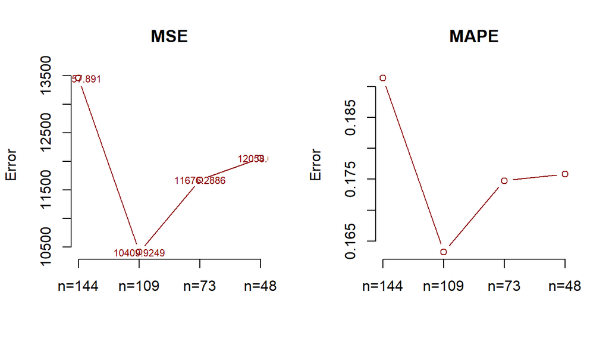

Comparing forecast errors

````r
par(mfrow=c(1,2))
plot(1:4, MSE, type="b", col="darkred", ylab="Error", xlab="",
     #ylim=c(0.4,.85),xlim = c(0.5,4.5),
     main="MSE", axes=FALSE)
labs=c("n=144", "n=109", "n=73", "n=48")
axis(1, at=1:4, label=labs)
axis(2)
#lines(1:4, MAPE, type="b", col="blue")
text(1:4, MAPE+0.03, as.character(round(MAPE,4)), col="blue", cex=0.7)
text(1:4, MSE-0.03, as.character(round(MSE,4)), col="darkred", cex=0.7)
legend(1.5, 0.63, c("MSE", "MAPE"), col=c("darkred","blue"), lty=1, bty="n", cex=0.7)
###
#```{r fig.align='center', fig.cap= "Comparing forecast errors", fig.width=5, fig.height=3.5}
plot(1:4, MAPE, type="b", col="darkred", ylab="Error", xlab="",
     #ylim=c(0.4,.85),xlim = c(0.5,4.5),
     main="MAPE", axes=FALSE)
labs=c("n=144", "n=109", "n=73", "n=48")
axis(1, at=1:4, label=labs)
axis(2)
````